# Analise RNASeq a celulas humanas TNBC

### 3.2.5 Cálculo distância entre amostras

```r
sampleDists <- dist(t(assay(vsd)))
sampleDistMatrix <- as.matrix(sampleDists)
rownames(sampleDistMatrix) <- dds$condition
colnames(sampleDistMatrix) <- NULL

head(sampleDistMatrix)
```

```
##              [,1]     [,2]     [,3]     [,4]     [,5]     [,6]
## bulk     0.000000 2.082840 2.025569 3.687577 4.121818 3.150809
## bulk     2.082840 0.000000 1.705190 3.563977 3.938674 2.971548
## bulk     2.025569 1.705190 0.000000 3.629396 4.077397 3.013044
## spheroid 3.687577 3.563977 3.629396 0.000000 2.148607 2.526703
## spheroid 4.121818 3.938674 4.077397 2.148607 0.000000 2.846689
## spheroid 3.150809 2.971548 3.013044 2.526703 2.846689 0.000000
```

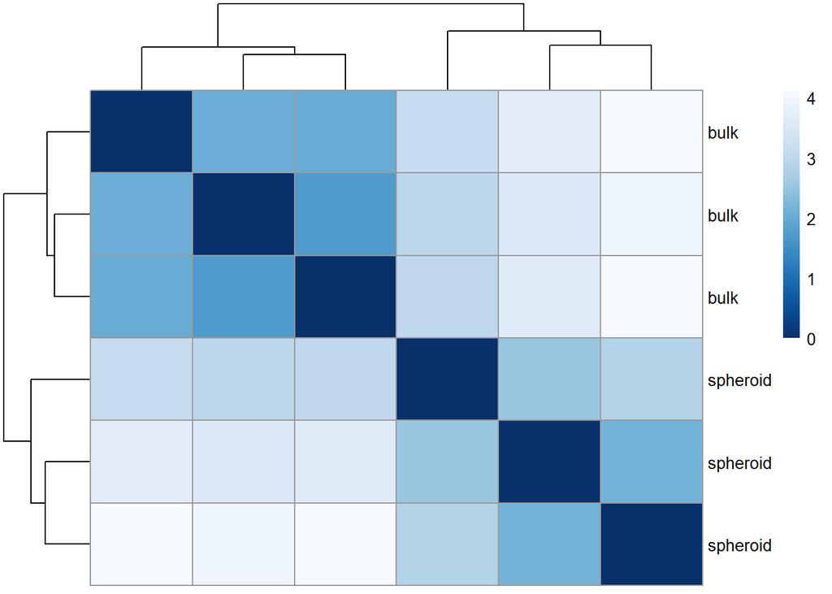

```r
colors <- colorRampPalette(rev(brewer.pal(9, "Blues")))(255)
#Heatmap com distancias
pheatmap(
  sampleDistMatrix,
  clustering_distance_rows = sampleDists,
  clustering_distance_cols = sampleDists,
  col = colors
)
```

**Heatmap da matriz de distância** dá nos uma visão geral das semelhanças e diferenças entre as amostras. Que mais uma vez confirma o agrupamento das samples sob a condição *bulk* e *spheroid*.

### 3.2.6 Principal Component Analysis (PCA)

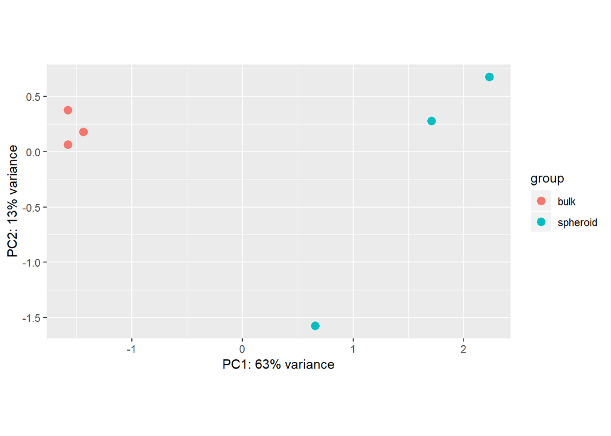

```r
plotPCA(vsd, intgroup = c("condition"))
```

#Conclusões

Infelizmente a ausência de valores de contagem previos não permite validar os resultados. No entanto, os resultados não indicam qualquer diferença significativa para a expressão dos genes BRCA1(ENSG00000012048) e BRCA2(ENSG00000139618) o que demostra a ineficiência em ambos os meios no tratamento TNBC nesta cultura celular.

#Referências

- Chavez K., et. al. Triple Negative Breast Cancer Cell Lines: One Toll, in the search for better treatment of triple Negative breast cancer. Breast Dis. Author manuscript. 2010. 32(1-2):35-48;
- McCarthy, Davis J, and Gordon K Smyth. 2009. “Testing significance relative to a fold-change threshold is a TREAT.” Bioinformatics (Oxford, England) 25 (6): 765–71; -Robinson, M D, D J McCarthy, and G K Smyth. 2010. “edgeR: a Bioconductor package for differential expression analysis of digital gene expression data.” Bioinformatics 26 (1). Oxford Univ Press: 139–40; -Law, Charity W, Yunshun Chen, Wei Shi, and Gordon K Smyth. 2014. “Voom: precision weights unlock linear model analysis tools for RNA-seq read counts.” Genome Biology 15 (2): R29;
- Love M, Anders S, Wolfgang H. Moderated estimation of fold change and dispersion for RNA-seq data with DESeq2.Genome Biology. 2014, 15:550;
- Love M, Anders S, Wolfgang H. BioC2014: RNA-Seq workflow fordiferential gene expression. Harvard School of Public Health. 2014;
- Robinson M, et al. edgeR: a bioconductor package for differential expression analysis digital gene expression data. Bioinformatics, ISCB. 2010, 26(1);
- BootstRatio: A web-based stastitical analysis of fold-change in qPCR and RT-qPCR data using resampling methods.Computers in Biology and Medicine. 2012, 42(4):438-45.